# Python Data Night - How to make your data shine

## Ádám Divák & Ágoston Török

## Synetiq

# Interactive data visualisations

Why should I care?

# Get answers and tell stories

1 Make data look and 'feel' better

- Amaze your clients and boss
- Increase engagement

2 Make it easier to get answers

- Explore important parts by moving, zooming, rotating
- Highlight exact values at points of interest
- Do all this without writing code!

3 Uncover hidden meaning

- Change parameters and immediately see the changes
- Chain visualisations together and see how they affect each other
- Create streaming, animated or otherwise customised visuals

> Interactivity is not the goal, but a means to an end.

# Prerequisites

```python
# Python
print('Hello Python!')
```

```
Hello Python!
```

```python
# Pandas
import pandas as pd
```

```python
df = pd.DataFrame({'column_1': [1, 2, 3, 2, 3, 2, 4], 'column_2': [4, 5, 6, 4, 4, 7, 9]})
df.head()
```

|  | column_1 | column_2 |
| --- | --- | --- |
| 0 | 1 | 4 |
| 1 | 2 | 5 |
| 2 | 3 | 6 |
| 3 | 2 | 4 |
| 4 | 3 | 4 |

```python
# Plotly, Cufflinks
!pip install --upgrade plotly cufflinks
```

# Plot.ly

## Plot.ly 'core':

- Browser-based plot rendering system
- Based on D3.js
- Connectors for Python, R, Matlab, Julia, JavaScript
  - Converters from Matplotlib, ggplot2, etc.
- Free, open-source
  - Yes, really.

## Additionally:

- Online hosting for plots & data
- Visual plot editor (no coding)
- Dashboard editor
- Presentation editor
- ...

*Some of these require a premium account*

# Plot.ly

```python
pyt.embed('https://plot.ly/~Dreamshot/8136')
```

[interactive chart not shown]

Credit: [Tyler Vigen](http://tylervigen.com/spurious-correlations), [Plot.ly blog](http://blog.plot.ly/post/146891210217/spurious-correlations)

# How to use Plot.ly

# How to use Plot.ly - convert from `matplotlib`

Original `matplotlib` version

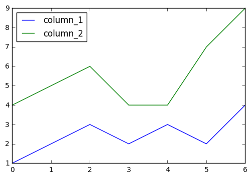

```python
mpl_plot = df.plot()
```

# How to use Plot.ly - convert from `matplotlib`

- `iplot` - interactive plotting (interactive == in a notebook)
- `mpl` - converting from `matplotlib`

```python
py.iplot_mpl(mpl_plot.get_figure())
```

[interactive chart not shown]

# How to use Plot.ly - native Plot.ly API

```python
trace1 = pygo.Bar(
    x=['giraffes', 'orangutans', 'monkeys'],
    y=[20, 14, 23],
    name='SF Zoo'
)
trace2 = pygo.Bar(
    x=['giraffes', 'orangutans', 'monkeys'],
    y=[12, 18, 29],
    name='LA Zoo'
)

data = [trace1, trace2]
layout = pygo.Layout(
    barmode='group',
    width=640
)

fig = pygo.Figure(data=data, layout=layout)
```

```python
py.iplot(fig)
```

[interactive chart not shown]

Credit: [Plot.ly tutorials](https://plot.ly/python/bar-charts/)

# How to use Plot.ly - plot directly from a DataFrame

**Plot.ly + Pandas = Cufflinks**

Cufflinks is *awesome*, check out [the examples](https://plot.ly/ipython-notebooks/cufflinks/)

```python
import cufflinks as cf
```

```python
df.iplot(kind='scatter')
```

[interactive chart not shown]

# How to use Plot.ly - plot 'offline'

`plotly.plotly` ( `py` )

**vs**

`plotly.offline` ( `pyoff` )

```python
pyoff.iplot_mpl(mpl_plot.get_figure())
```

[interactive chart not shown]

# The data

Source: Data visualisation challenge of [satRday](https://budapest.satrdays.org/)

```python
df = pd.read_excel(filename, engine='xlrd')
df.head()
```

|  | DESTINATION | COMMERCIAL FLAG | CITY | REGION | COUNTRY | FLIGH DIRECTION | FLIGHT TYPE | DATE | DATE YEAR | DATE HALF YEAR | DATE YEAR QUARTER | DATE YEAR MONTH | NBR OF PASSENGERS | CARGO WEIGHT | NBR OF FLIGHTS | SEAT CAPACITY |
| --- | --- | --- | --- | --- | --- | --- | --- | --- | --- | --- | --- | --- | --- | --- | --- | --- |
| 0 | Aalborg | Commercial | Aalborg | NaN | Denmark | Incoming | Non Scheduled | 2010-11-01 | 2010 | 2010H2 | 2010Q4 | 201011 | 0 | 0 | 1 | 0 |
| 1 | Aalborg | Commercial | Aalborg | NaN | Denmark | Outgoing | Non Scheduled | 2010-12-01 | 2010 | 2010H2 | 2010Q4 | 201012 | 0 | 0 | 1 | 0 |
| 2 | Aalborg | Commercial | Aalborg | NaN | Denmark | Incoming | Non Scheduled | 2011-01-01 | 2011 | 2011H1 | 2011Q1 | 201101 | 0 | 0 | 1 | 0 |
| 3 | Aarhus | Commercial | Aarhus | NaN | Denmark | Incoming | Non Scheduled | 2007-05-01 | 2007 | 2007H1 | 2007Q2 | 200705 | 102 | 0 | 1 | 200 |
| 4 | Aberdeen | Commercial | Aberdeen | NaN | United Kingdom | Outgoing | Non Scheduled | 2011-07-01 | 2011 | 2011H2 | 2011Q3 | 201107 | 0 | 0 | 1 | 0 |

# Why use interactive plots?

# 1. Make your data look and feel better

- Turn existing plots into interactive ones with one line
- Do it while working in Jupyter
- Embed it in a web page
  - Or export it to high-quality images
- Edit the style in Plot.ly's web editor

# 2. Make it easier to get answers

## 2. Make it easier to get answers - zoom, highlight

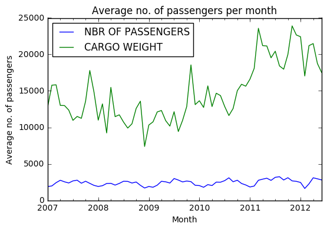

```python
# Generate in `matplotlib`
df['Month'] = df.loc[:,'DATE']
data = df.groupby('Month').mean().loc[:,['NBR OF PASSENGERS', 'CARGO WEIGHT']]
data.plot()
plt.ylabel('Average no. of passengers')
plt.title('Average no. of passengers per month')
```

```python
data.iplot()
```

[interactive chart not shown]

## 2. Make it easier to get answers - annotate

Do a little geo-coding so we can draw a map from the data

```python
import geocoder

cities = df.loc[:,'CITY'].drop_duplicates()
cities = cities.reset_index(drop = True)
coordinates = pd.DataFrame(cities.apply(lambda x:
                                        tuple(geocoder.google(x).latlng)).values.tolist())

cities_coor = pd.concat([cities, coordinates], axis = 1, ignore_index= True)
cities_coor.columns = ['CITY', 'LAT', 'LON']
df = df.merge(cities_coor)
```

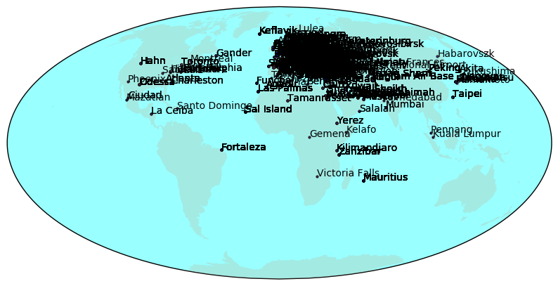

```python
from mpl_toolkits.basemap import Basemap

plt.figure(figsize=(10,10))
m = Basemap(projection='moll',lon_0=0)
m.drawmapboundary(fill_color='#99ffff')
x, y = m(df['LON'].values, df['LAT'].values)
m.fillcontinents(color='#cc9977',lake_color='#99ffff', alpha = 0.2)
m.scatter(x,y,4)
for ind in range(len(df)):
    plt.annotate(df.iloc[ind].loc['CITY'], (x[ind], y[ind]))
pass
```

```python
df2 = df.groupby('CITY').mean().reset_index().dropna(subset=['LON'])
df2['text'] = 'Destination is: ' + df2['CITY'] + '<br>Mean passengers in the direction: ' + df2['NBR OF PASSENGERS'].astype(str)


data = [ dict(
        type = 'scattergeo',
        locationmode = 'World',
        lon = df2['LON'],
        lat = df2['LAT'],
        text = df2['text'],
        mode = 'markers',
        marker = dict(
            size = df['NBR OF PASSENGERS'] / 50,
            opacity = 0.8,
            reversescale = True,
            autocolorscale = False,
            symbol = 'circle',
            line = dict(
                width=1,
                color='rgba(102, 102, 102)'
            ),
            colorscale = 'Jet',
            cmin = 0,
            color = df['NBR OF PASSENGERS'],
            cmax = df['NBR OF PASSENGERS'].max(),
            colorbar=dict(
                title="Average # of passengers"
            )
        ))]

layout = dict(
        title = 'Most trafficked airports from BUD<br>(Hover for airport names and traffic)',
        colorbar = True,
        geo = dict(
            scope='world',
            projection=dict( type='mollweide' ),
            showland = True,
            landcolor = "rgb(250, 250, 250)",
            subunitcolor = "rgb(217, 217, 217)",
            countrycolor = "rgb(217, 217, 217)",
            countrywidth = 0.5,
            subunitwidth = 0.5
        ),
    )

fig = dict( data=data, layout=layout )
```

```python
py.iplot( fig, validate=False, filename='d3-airports' )
```

[interactive chart not shown]

## 2. Make it easier to get answers - rotate

```python
pyt.embed('https://plot.ly/~kevintest/1067')
```

[interactive chart not shown]

# Giving deeper meaning to the data

```python
data = df.loc[:, ['DATE', 'NBR OF PASSENGERS', 'CARGO WEIGHT', 'NBR OF FLIGHTS']]
data = data.set_index('DATE')
data = data.groupby(level=0).mean()
data = data.sort_index()
data.head()
```

| DATE | NBR OF PASSENGERS | CARGO WEIGHT | NBR OF FLIGHTS |
| --- | --- | --- | --- |
| 2007-01-01 | 1887.309701 | 12784.376866 | 30.996269 |
| 2007-02-01 | 1969.375000 | 15785.383333 | 32.241667 |
| 2007-03-01 | 2414.832031 | 15829.097656 | 35.015625 |
| 2007-04-01 | 2746.496094 | 13008.511719 | 36.410156 |
| 2007-05-01 | 2532.731034 | 12988.162069 | 34.503448 |

## Giving deeper meaning to the data - share interaction

```python
data.iplot(subplots=True, shape=(4,1), shared_xaxes=True, fill=True)
```

[interactive chart not shown]

## Giving deeper meaning to the data - show multiple aspects of the same information

```python
data.scatter_matrix()
```

[interactive chart not shown]

## Giving deeper meaning to the data - show multiple aspects of the same information

```python
Budapest = geocoder.google("Budapest").latlng
colorscale = ['#7A4579', '#D56073', 'rgb(236,158,105)', (1, 1, 0.2), (0.98,0.98,0.98)]

layout = pygo.Layout(
    title='Plot Title')

fig = FF.create_2D_density(
    df['LAT'], df['LON'], colorscale=colorscale,
    hist_color='rgb(255, 237, 222)', point_size=3
)

source_point = pygo.Scatter(x=Budapest[0], y=Budapest[1],
                          mode='markers',
                          marker=pygo.Marker(size=20),
                          name='Budapest')

fig['data'].append(source_point)
```

```python
py.iplot(fig, filename='histogram_subplots')
```

[interactive chart not shown]

## Giving deeper meaning to the data - Interact with the plots

```python
colorscale = ['#7A4579', '#D56073', 'rgb(236,158,105)', (1, 1, 0.2), (0.98,0.98,0.98)]

from plotly.graph_objs import graph_objs as go
from IPython.html.widgets import interact

df['Month'] = df['DATE'].dt.month
def view_image(w):
    fig = FF.create_2D_density(
    df.loc[df.Month == w, 'LON'], df.loc[df.Month == w, 'LAT'], colorscale=colorscale,
    hist_color='rgb(255, 237, 222)', point_size=3
    )

    source_point = go.Scatter(x=Budapest[0], y=Budapest[1],
                              mode='markers',
                              marker=go.Marker(size=20),
                              name='Budapest')

    fig['data'].append(source_point)
    #fig['layout']['title'] = ''
    iplot(fig)
```

```python
interact(view_image, w=(1,12))
```

[interactive chart not shown]

```
<function __main__.view_image>
```

# Giving deeper meaning to the data - [Dashboards!](https://plot.ly/python/dashboard/)

Add widgets, filter data

## Giving deeper meaning to the data - Create custom widgets

```python
%%HTML
<video width="640" height="480" controls>
  <source src="custom_video_player.ogg" type="video/ogg">
</video>
```

[video not shown]

# Closing thoughts

- Plot.ly has many more features I couldn’t showcase
  - Curve fitting, on-premise hosted, other languages, etc.
- You milage may vary
  - There are other tools that might be better suited for your needs
  - Spectrum goes from ‘versatile but difficult to program’ to ‘readily available but less customisable’
  - D3.js, bokeh, Vincent/Vega, ggplot, (gnuplot) ---> Tableau, Microsoft PowerBI, Grafana, Geckoboard, etc.

# Thank you!

## Questions?

## Get this notebook on [GitHub/Synetiq](https://github.com/Synetiq/2016_python_data_night)

## We're hiring :)

```python
!jupyter nbconvert --to slides PythonDataNight.ipynb --reveal-prefix=reveal.js
import random
print(random.randint(0, 100))
```

```
[NbConvertApp] Converting notebook PythonDataNight.ipynb to slides
[NbConvertApp] Writing 632379 bytes to PythonDataNight.slides.html
29
```